# Lab 1

Sam Fritz-Schreck

2023-07-05

## Week 2 Part 1: Regression analysis on the “Credit” dataset

In the take-home lab exercise you will go through what we did in the lab with “Credit” dataset from “ISLR” package. Here we apply the best subset selection approach to the “Credit” dataset. This means that we would like to predict a person’s “Balance” on the basis of various statistics associated with performance in the previous year.

“Credit” dataset is in “ISLR” library. So simply call “ISLR” library and call “Credit”.

```r
library(ISLR)
data(Credit)
summary(Credit)
```

```
##        ID            Income           Limit           Rating
##  Min.   :  1.0   Min.   : 10.35   Min.   :  855   Min.   : 93.0
##  1st Qu.:100.8   1st Qu.: 21.01   1st Qu.: 3088   1st Qu.:247.2
##  Median :200.5   Median : 33.12   Median : 4622   Median :344.0
##  Mean   :200.5   Mean   : 45.22   Mean   : 4736   Mean   :354.9
##  3rd Qu.:300.2   3rd Qu.: 57.47   3rd Qu.: 5873   3rd Qu.:437.2
##  Max.   :400.0   Max.   :186.63   Max.   :13913   Max.   :982.0
##      Cards            Age          Education        Gender    Student
##  Min.   :1.000   Min.   :23.00   Min.   : 5.00    Male :193   No :360
##  1st Qu.:2.000   1st Qu.:41.75   1st Qu.:11.00   Female:207   Yes: 40
##  Median :3.000   Median :56.00   Median :14.00
##  Mean   :2.958   Mean   :55.67   Mean   :13.45
##  3rd Qu.:4.000   3rd Qu.:70.00   3rd Qu.:16.00
##  Max.   :9.000   Max.   :98.00   Max.   :20.00
##  Married              Ethnicity      Balance
##  No :155   African American: 99   Min.   :   0.00
##  Yes:245   Asian           :102   1st Qu.:  68.75
##            Caucasian       :199   Median : 459.50
##                                   Mean   : 520.01
##                                   3rd Qu.: 863.00
##                                   Max.   :1999.00
```

```r
set.seed(1)
train <- sample(1:nrow(Credit), round(nrow(Credit))/2)

test <- (-train)

credit.train = Credit[train,]
credit.test = Credit[test,]
```

## Question 1

Use the multiple linear regression, pick the features you think the best via stepwise feature selection, BIC, Cp and adjusted R2.

### Features Selected

Stepwise: Balance ~ Income + Limit + Cards + Age + Student

Adj R2 : Balance ~ Income + Limit + Cards + Age + Student

CP: Balance ~ Income + Limit + Cards + Age + Student

BIC: Balance ~ Income + Limit + Cards + Age + Student

```r
# Stepwise Feature Selection
lm.fit<-lm(Balance ~., credit.train)
summary(lm.fit)
```

```
##
## Call:
## lm(formula = Balance ~ ., data = credit.train)
##
## Residuals:
##     Min      1Q  Median      3Q     Max
## -144.59  -73.95  -16.00   49.87  332.71
##
## Coefficients:
##                      Estimate Std. Error t value Pr(>|t|)
## (Intercept)        -447.73761   52.86431  -8.470 7.14e-15 ***
## ID                    0.03469    0.06194   0.560 0.576095
## Income               -7.63537    0.33685 -22.667  < 2e-16 ***
## Limit                 0.26099    0.04731   5.517 1.14e-07 ***
## Rating                0.12822    0.70771   0.181 0.856427
## Cards                20.72986    6.07619   3.412 0.000791 ***
## Age                  -1.20547    0.44119  -2.732 0.006892 **
## Education            -0.19274    2.21690  -0.087 0.930813
## GenderFemale         -9.67537   14.16462  -0.683 0.495411
## StudentYes          426.87567   23.09401  18.484  < 2e-16 ***
## MarriedYes           -9.03727   14.90925  -0.606 0.545149
## EthnicityAsian       -2.57974   20.22767  -0.128 0.898654
## EthnicityCaucasian   -4.96461   17.80072  -0.279 0.780630
## ---
## Signif. codes:  0 '***' 0.001 '**' 0.01 '*' 0.05 '.' 0.1 ' ' 1
##
## Residual standard error: 98.07 on 187 degrees of freedom
## Multiple R-squared:  0.9605, Adjusted R-squared:  0.958
## F-statistic: 378.9 on 12 and 187 DF,  p-value: < 2.2e-16
```

```r
# Conduct stepwise model selection
regfit.step<-step(lm.fit, direction = "both")
```

```
## Start:  AIC=1846.84
## Balance ~ ID + Income + Limit + Rating + Cards + Age + Education +
##     Gender + Student + Married + Ethnicity
##
##             Df Sum of Sq     RSS    AIC
## - Ethnicity  2       778 1799419 1842.9
## - Education  1        73 1798714 1844.8
## - Rating     1       316 1798957 1844.9
## - ID         1      3017 1801659 1845.2
## - Married    1      3534 1802176 1845.2
## - Gender     1      4488 1803129 1845.3
## <none>                   1798642 1846.8
## - Age        1     71806 1870448 1852.7
## - Cards      1    111952 1910594 1856.9
## - Limit      1    292746 2091387 1875.0
## - Student    1   3286301 5084943 2052.7
## - Income     1   4941732 6740373 2109.1
##
## Step:  AIC=1842.93
## Balance ~ ID + Income + Limit + Rating + Cards + Age + Education +
##     Gender + Student + Married
##
##             Df Sum of Sq     RSS    AIC
## - Education  1        45 1799464 1840.9
## - Rating     1       370 1799790 1841.0
## - ID         1      2703 1802123 1841.2
## - Married    1      3654 1803073 1841.3
## - Gender     1      4491 1803910 1841.4
## <none>                   1799419 1842.9
## + Ethnicity  2       778 1798642 1846.8
## - Age        1     71176 1870596 1848.7
## - Cards      1    111912 1911332 1853.0
## - Limit      1    298242 2097662 1871.6
## - Student    1   3288959 5088378 2048.8
## - Income     1   4971095 6770514 2105.9
##
## Step:  AIC=1840.94
## Balance ~ ID + Income + Limit + Rating + Cards + Age + Gender +
##     Student + Married
##
```

[output cut: 67 more lines]

```
## Balance ~ Income + Limit + Cards + Age + Student
##
##             Df Sum of Sq      RSS    AIC
## <none>                    1811213 1834.2
## + Gender     1      5602  1805611 1835.6
## + ID         1      3390  1807823 1835.9
## + Married    1      2990  1808223 1835.9
## + Rating     1       173  1811040 1836.2
## + Education  1        49  1811164 1836.2
## + Ethnicity  2       568  1810645 1838.2
## - Age        1     72030  1883243 1840.0
## - Cards      1    194180  2005393 1852.6
## - Student    1   3447412  5258625 2045.4
## - Income     1   5003222  6814435 2097.2
## - Limit      1  26252594 28063807 2380.3
```

```r
# Summarize the selected model
summary(regfit.step)
```

```
##
## Call:
## lm(formula = Balance ~ Income + Limit + Cards + Age + Student,
##     data = credit.train)
##
## Residuals:
##     Min      1Q  Median      3Q     Max
## -150.64  -74.14  -15.33   51.43  329.20
##
## Coefficients:
##               Estimate Std. Error t value Pr(>|t|)
## (Intercept) -4.550e+02  3.235e+01 -14.062  < 2e-16 ***
## Income      -7.601e+00  3.283e-01 -23.149  < 2e-16 ***
## Limit        2.690e-01  5.073e-03  53.028  < 2e-16 ***
## Cards        2.175e+01  4.770e+00   4.561 9.03e-06 ***
## Age         -1.191e+00  4.288e-01  -2.778  0.00601 **
## StudentYes   4.290e+02  2.233e+01  19.216  < 2e-16 ***
## ---
## Signif. codes:  0 '***' 0.001 '**' 0.01 '*' 0.05 '.' 0.1 ' ' 1
##
## Residual standard error: 96.62 on 194 degrees of freedom
## Multiple R-squared:  0.9602, Adjusted R-squared:  0.9592
## F-statistic: 936.7 on 5 and 194 DF,  p-value: < 2.2e-16
```

```r
# Best Subset
library(leaps)
regfit.full <- regsubsets(Balance ~., credit.train, nvmax = 12)
summary(regfit.full)
```

```
## Subset selection object
## Call: regsubsets.formula(Balance ~ ., credit.train, nvmax = 12)
## 12 Variables  (and intercept)
##                    Forced in Forced out
## ID                     FALSE      FALSE
## Income                 FALSE      FALSE
## Limit                  FALSE      FALSE
## Rating                 FALSE      FALSE
## Cards                  FALSE      FALSE
## Age                    FALSE      FALSE
## Education              FALSE      FALSE
## GenderFemale           FALSE      FALSE
## StudentYes             FALSE      FALSE
## MarriedYes             FALSE      FALSE
## EthnicityAsian         FALSE      FALSE
## EthnicityCaucasian     FALSE      FALSE
## 1 subsets of each size up to 12
## Selection Algorithm: exhaustive
##           ID  Income Limit Rating Cards Age Education GenderFemale StudentYes
## 1  ( 1 )  " " " "    " "   "*"    " "   " " " "       " "          " "
## 2  ( 1 )  " " "*"    " "   "*"    " "   " " " "       " "          " "
## 3  ( 1 )  " " "*"    "*"   " "    " "   " " " "       " "          "*"
## 4  ( 1 )  " " "*"    "*"   " "    "*"   " " " "       " "          "*"
## 5  ( 1 )  " " "*"    "*"   " "    "*"   "*" " "       " "          "*"
## 6  ( 1 )  " " "*"    "*"   " "    "*"   "*" " "       "*"          "*"
## 7  ( 1 )  " " "*"    "*"   " "    "*"   "*" " "       "*"          "*"
## 8  ( 1 )  "*" "*"    "*"   " "    "*"   "*" " "       "*"          "*"
## 9  ( 1 )  "*" "*"    "*"   " "    "*"   "*" " "       "*"          "*"
## 10  ( 1 ) "*" "*"    "*"   "*"    "*"   "*" " "       "*"          "*"
## 11  ( 1 ) "*" "*"    "*"   "*"    "*"   "*" " "       "*"          "*"
## 12  ( 1 ) "*" "*"    "*"   "*"    "*"   "*" "*"       "*"          "*"
##           MarriedYes EthnicityAsian EthnicityCaucasian
## 1  ( 1 )  " "        " "            " "
## 2  ( 1 )  " "        " "            " "
## 3  ( 1 )  " "        " "            " "
## 4  ( 1 )  " "        " "            " "
## 5  ( 1 )  " "        " "            " "
## 6  ( 1 )  " "        " "            " "
## 7  ( 1 )  "*"        " "            " "
## 8  ( 1 )  "*"        " "            " "
## 9  ( 1 )  "*"        " "            "*"
## 10  ( 1 ) "*"        " "            "*"
## 11  ( 1 ) "*"        "*"            "*"
## 12  ( 1 ) "*"        "*"            "*"
```

```r
res.sum <- summary(regfit.full)
R2 = which.max(res.sum$adjr2)
CP = which.min(res.sum$cp)
BIC = which.min(res.sum$bic)

# Adjusted R2
R2.formula = get_model_formula(R2, regfit.full, "Balance")

# CP
CP.formula = get_model_formula(CP, regfit.full, "Balance")

# BIC
BIC.formula = get_model_formula(BIC, regfit.full, "Balance")
```

Compare Lasso and Ridge regression on “Credit” dataset.

```r
# Ridge Regression
x <- model.matrix(Balance~.,Credit)
y <- Credit$Balance

set.seed(1)
train <- sample(1:nrow(x), round(nrow(x))/2)

test <- (-train)
### We are setting training sets for the explanatory variables x and response variable y
x.train <- x[train,]
y.train <- y[train]
### We are setting test sets for the explanatory variables x and response variable y
x.test <- x[test,]
y.test <- y[test]

library(glmnet)
```

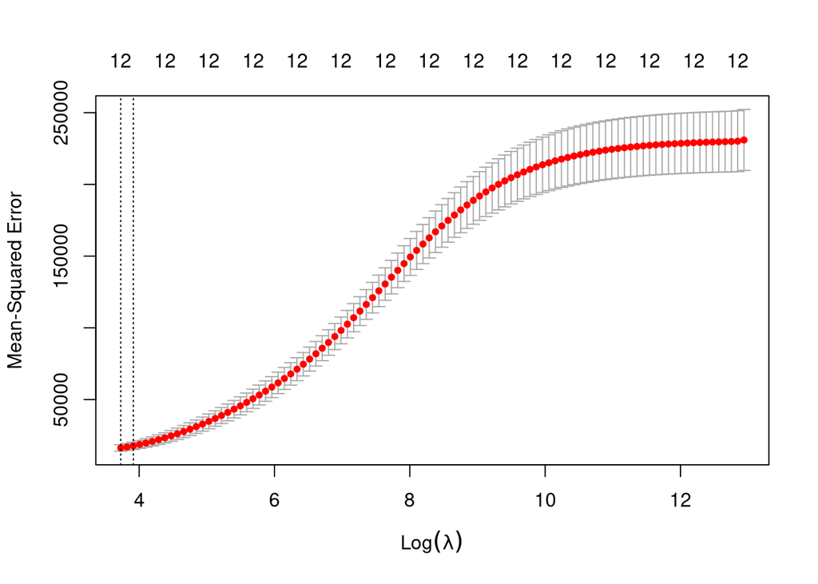

```r
grid <- 10^seq(10,-2,length=100)

ridge.mod <- glmnet(x.train, y.train, alpha = 0, lambda = grid, thresh = 1e-12)

set.seed (1)
cv.out <- cv.glmnet(x.train, y.train, alpha = 0)
plot(cv.out)
```

```r
bestlam.ridge <- cv.out$lambda.min
bestlam.ridge
```

```
## [1] 41.60385
```

```r
ridge.pred <- predict(ridge.mod, s=bestlam.ridge, newx=x.test)
## This is MSE with the test set
ridge.MSE = mean((ridge.pred - y.test)^2)
out <- glmnet(x,y,alpha=0)
predict(out, type="coefficients", s=bestlam.ridge)
```

```
## 14 x 1 sparse Matrix of class "dgCMatrix"
##                               s1
## (Intercept)        -402.69174822
## (Intercept)           .
## ID                    0.02968823
## Income               -5.08362998
## Limit                 0.11363315
## Rating                1.65055380
## Cards                15.94593669
## Age                  -0.97611320
## Education            -0.46045505
## GenderFemale         -3.91626143
## StudentYes          380.23436720
## MarriedYes          -12.29347706
## EthnicityAsian       13.01622062
## EthnicityCaucasian    8.53524735
```

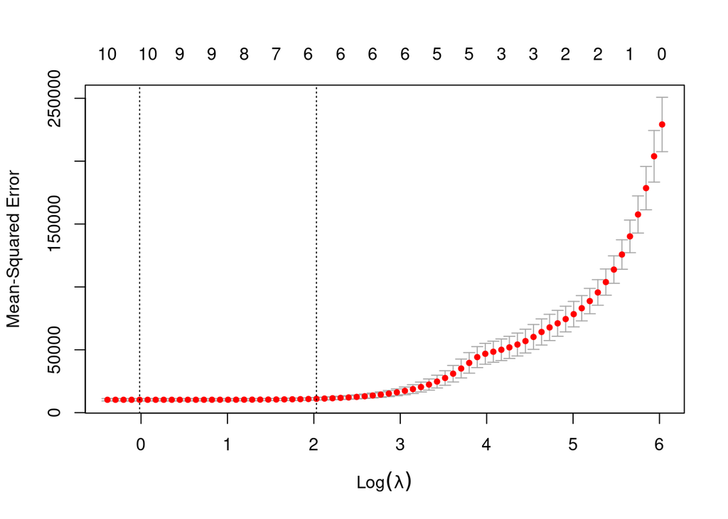

```r
# Lasso Regression
library(glmnet)
grid <- 10^seq(10,-2,length=100)

ridge.mod <- glmnet(x.train, y.train, alpha = 1, lambda = grid, thresh = 1e-12)

set.seed (1)
cv.out <- cv.glmnet(x.train, y.train, alpha = 1)
plot(cv.out)
```

```r
bestlam.lasso <- cv.out$lambda.min
bestlam.lasso
```

```
## [1] 0.9837185
```

```r
lasso.pred <- predict(ridge.mod, s=bestlam.lasso, newx=x.test)
## This is MSE with the test set
lasso.MSE = mean((lasso.pred - y.test)^2)
out <- glmnet(x,y,alpha=1)
predict(out, type="coefficients", s=bestlam.lasso)
```

```
## 14 x 1 sparse Matrix of class "dgCMatrix"
##                               s1
## (Intercept)        -489.58624674
## (Intercept)           .
## ID                    0.03262995
## Income               -7.67447155
## Limit                 0.17397332
## Rating                1.35815214
## Cards                16.16522787
## Age                  -0.59457537
## Education            -0.73206632
## GenderFemale         -7.47511444
## StudentYes          421.58437848
## MarriedYes           -6.96638623
## EthnicityAsian       11.47172762
## EthnicityCaucasian    4.71782455
```

```r
lm.R2 = lm(Balance ~ Income + Limit + Cards + Age + Student, data=credit.train)
R2.pred = predict(lm.R2, newdata=credit.test)
R2.MSE = mean((credit.test$Balance-R2.pred)^2)

lm.CP = lm(Balance ~ Income + Limit + Cards + Age + Student, data=credit.train)
CP.pred = predict(lm.CP, newdata=credit.test)
CP.MSE = mean((credit.test$Balance-CP.pred)^2)

lm.BIC = lm(Balance ~ Income + Limit + Cards + Age + Student, data=credit.train)
BIC.pred = predict(lm.BIC, newdata=credit.test)
BIC.MSE = mean((credit.test$Balance-BIC.pred)^2)
```

### Questions for Credit Data

What can you conclude from the analysis?

In both cases, income, cards, student, marriage, and ethnicity have large coefficients. Rating could also be significant even though it has a relatively low coefficient due its large value relative to the other metrics

Which one is the best?

Lasso performs better than ridge on the test set in this application

What are λ for Lasso and Ridge regression?

Ridge Regression: 41.604

Lasso Regression: 0.984

Compare the MSE for Ridge regression with selected variables via Best Subset Selection and Lasso. What do you think? How are they different?

Adj R2 MSE: 10738.54

CP MSE: 10738.54

BIC MSE: 10738.54

Ridge MSE: 16116.160

Lasso MSE: 10605.163

An argument could be made supporting Lasso or any of the best subset metric choices. For outright performance, I would choose Lasso as it has the best MSE on the testing data but for greater interpretability I would choose the best subset solution.

Do you think lasso is better or Ridge regression?

Which explanatory variables are contributing to “Balance”? Which variables are selected via best subset selection?

In this case, both stepwise and all the best subset methods select the same variables to predict Balance.

Stepwise: Balance ~ Income + Limit + Cards + Age + Student

Adj R2 : Balance ~ Income + Limit + Cards + Age + Student

CP: Balance ~ Income + Limit + Cards + Age + Student

BIC: Balance ~ Income + Limit + Cards + Age + Student

## Week 2 Part 2: Regression analysis on the “Auto” dataset

In the second part of the take-home lab exercise you will go through what we did in the lab with “Auto” dataset from “ISLR” package. Here we apply the best subset selection approach to the “Auto” dataset. This means that we would like to predict a car’s “mpg” on the basis of various statistics associated with each car’s functionality and origin.

There is a tricky part for this exercise. Namely we need to think how to deal with origin since it is a categorical variable (not a numerical). Also name variable has a lot of levels in this categorical variable.

“Auto” dataset is in “ISLR” library. So simply call “ISLR” library and call “Auto”.

```r
library(ISLR)
data(Auto)
summary(Auto)
```

```
##       mpg          cylinders      displacement     horsepower        weight
##  Min.   : 9.00   Min.   :3.000   Min.   : 68.0   Min.   : 46.0   Min.   :1613
##  1st Qu.:17.00   1st Qu.:4.000   1st Qu.:105.0   1st Qu.: 75.0   1st Qu.:2225
##  Median :22.75   Median :4.000   Median :151.0   Median : 93.5   Median :2804
##  Mean   :23.45   Mean   :5.472   Mean   :194.4   Mean   :104.5   Mean   :2978
##  3rd Qu.:29.00   3rd Qu.:8.000   3rd Qu.:275.8   3rd Qu.:126.0   3rd Qu.:3615
##  Max.   :46.60   Max.   :8.000   Max.   :455.0   Max.   :230.0   Max.   :5140
##
##   acceleration        year           origin                      name
##  Min.   : 8.00   Min.   :70.00   Min.   :1.000   amc matador       :  5
##  1st Qu.:13.78   1st Qu.:73.00   1st Qu.:1.000   ford pinto        :  5
##  Median :15.50   Median :76.00   Median :1.000   toyota corolla    :  5
##  Mean   :15.54   Mean   :75.98   Mean   :1.577   amc gremlin       :  4
##  3rd Qu.:17.02   3rd Qu.:79.00   3rd Qu.:2.000   amc hornet        :  4
##  Max.   :24.80   Max.   :82.00   Max.   :3.000   chevrolet chevette:  4
##                                                  (Other)           :365
```

Question 3

Answer the questions above for “Auto” dataset.

Use the multiple linear regression, pick the features you think the best via stepwise feature selection, BIC, Cp and adjusted R2.

```r
#convert origin to factors
Auto$origin = as.factor(Auto$origin)

set.seed(1)
train <- sample(1:nrow(Auto), round(nrow(Auto))/2)

test <- (-train)

auto.train = Auto[train,]
auto.test = Auto[test,]
```

Stepwise: mpg ~ weight + year + origin

```r
# Stepwise Feature Selection
lm.fit<-lm(mpg ~.-name, auto.train)
summary(lm.fit)
```

```
##
## Call:
## lm(formula = mpg ~ . - name, data = auto.train)
##
## Residuals:
##     Min      1Q  Median      3Q     Max
## -9.3032 -2.3745 -0.3337  1.9039  9.9763
##
## Coefficients:
##                Estimate Std. Error t value Pr(>|t|)
## (Intercept)  -2.060e+01  6.837e+00  -3.013  0.00295 **
## cylinders    -4.538e-01  4.817e-01  -0.942  0.34734
## displacement  1.305e-02  1.220e-02   1.070  0.28608
## horsepower   -2.044e-02  2.157e-02  -0.948  0.34446
## weight       -5.565e-03  9.114e-04  -6.106 5.78e-09 ***
## acceleration  6.248e-02  1.421e-01   0.440  0.66069
## year          7.995e-01  7.668e-02  10.427  < 2e-16 ***
## origin2       3.199e+00  8.723e-01   3.667  0.00032 ***
## origin3       2.804e+00  8.456e-01   3.316  0.00110 **
## ---
## Signif. codes:  0 '***' 0.001 '**' 0.01 '*' 0.05 '.' 0.1 ' ' 1
##
## Residual standard error: 3.537 on 187 degrees of freedom
## Multiple R-squared:  0.8185, Adjusted R-squared:  0.8107
## F-statistic: 105.4 on 8 and 187 DF,  p-value: < 2.2e-16
```

```r
# Conduct stepwise model selection
regfit.step<-step(lm.fit, direction = "both")
```

```
## Start:  AIC=504.05
## mpg ~ (cylinders + displacement + horsepower + weight + acceleration +
##     year + origin + name) - name
##
##                Df Sum of Sq    RSS    AIC
## - acceleration  1      2.42 2342.5 502.25
## - cylinders     1     11.11 2351.2 502.97
## - horsepower    1     11.24 2351.3 502.99
## - displacement  1     14.32 2354.4 503.24
## <none>                      2340.1 504.05
## - origin        2    211.47 2551.6 517.00
## - weight        1    466.58 2806.7 537.68
## - year          1   1360.50 3700.6 591.87
##
## Step:  AIC=502.25
## mpg ~ cylinders + displacement + horsepower + weight + year +
##     origin
##
##                Df Sum of Sq    RSS    AIC
## - cylinders     1     11.26 2353.8 501.19
## - displacement  1     13.47 2356.0 501.37
## <none>                      2342.5 502.25
## - horsepower    1     26.33 2368.8 502.44
## + acceleration  1      2.42 2340.1 504.05
## - origin        2    217.12 2559.6 515.62
## - weight        1    550.03 2892.5 541.59
## - year          1   1361.41 3703.9 590.05
##
## Step:  AIC=501.19
## mpg ~ displacement + horsepower + weight + year + origin
##
##                Df Sum of Sq    RSS    AIC
## - displacement  1      3.52 2357.3 499.48
## - horsepower    1     20.86 2374.6 500.92
## <none>                      2353.8 501.19
## + cylinders     1     11.26 2342.5 502.25
## + acceleration  1      2.57 2351.2 502.97
## - origin        2    208.96 2562.7 513.86
## - weight        1    575.03 2928.8 542.03
## - year          1   1362.61 3716.4 588.71
```

[output cut: 11 more lines]

```
## - weight        1    840.60 3197.9 557.26
## - year          1   1373.54 3730.8 587.47
##
## Step:  AIC=498.99
## mpg ~ weight + year + origin
##
##                Df Sum of Sq    RSS    AIC
## <none>                      2375.5 498.99
## + horsepower    1     18.18 2357.3 499.48
## + acceleration  1     15.21 2360.3 499.73
## + cylinders     1      5.53 2369.9 500.53
## + displacement  1      0.84 2374.6 500.92
## - origin        2    235.19 2610.7 513.49
## - year          1   1686.27 4061.7 602.13
## - weight        1   2800.50 5176.0 649.64
```

```r
# Summarize the selected model
summary(regfit.step)
```

```
##
## Call:
## lm(formula = mpg ~ weight + year + origin, data = auto.train)
##
## Residuals:
##     Min      1Q  Median      3Q     Max
## -9.4809 -2.3598 -0.2665  2.0281 10.7012
##
## Coefficients:
##               Estimate Std. Error t value Pr(>|t|)
## (Intercept) -2.287e+01  5.951e+00  -3.842 0.000166 ***
## weight      -5.811e-03  3.873e-04 -15.006  < 2e-16 ***
## year         8.254e-01  7.089e-02  11.644  < 2e-16 ***
## origin2      3.223e+00  8.036e-01   4.011 8.69e-05 ***
## origin3      2.433e+00  7.717e-01   3.153 0.001874 **
## ---
## Signif. codes:  0 '***' 0.001 '**' 0.01 '*' 0.05 '.' 0.1 ' ' 1
##
## Residual standard error: 3.527 on 191 degrees of freedom
## Multiple R-squared:  0.8157, Adjusted R-squared:  0.8119
## F-statistic: 211.4 on 4 and 191 DF,  p-value: < 2.2e-16
```

Best Subsets:

BIC: mpg ~ weight + year + origin2 + origin3

CP: mpg ~ weight + year + origin2 + origin3

Adj R2: mpg ~ horsepower + weight + year + origin2 + origin3

```r
# Best Subset
library(leaps)
regfit.full <- regsubsets(mpg ~. -name, auto.train, nvmax = 7)
summary(regfit.full)
```

```
## Subset selection object
## Call: regsubsets.formula(mpg ~ . - name, auto.train, nvmax = 7)
## 8 Variables  (and intercept)
##              Forced in Forced out
## cylinders        FALSE      FALSE
## displacement     FALSE      FALSE
## horsepower       FALSE      FALSE
## weight           FALSE      FALSE
## acceleration     FALSE      FALSE
## year             FALSE      FALSE
## origin2          FALSE      FALSE
## origin3          FALSE      FALSE
## 1 subsets of each size up to 7
## Selection Algorithm: exhaustive
##          cylinders displacement horsepower weight acceleration year origin2
## 1  ( 1 ) " "       " "          " "        "*"    " "          " "  " "
## 2  ( 1 ) " "       " "          " "        "*"    " "          "*"  " "
## 3  ( 1 ) " "       " "          " "        "*"    " "          "*"  "*"
## 4  ( 1 ) " "       " "          " "        "*"    " "          "*"  "*"
## 5  ( 1 ) " "       " "          "*"        "*"    " "          "*"  "*"
## 6  ( 1 ) " "       "*"          "*"        "*"    " "          "*"  "*"
## 7  ( 1 ) "*"       "*"          "*"        "*"    " "          "*"  "*"
##          origin3
## 1  ( 1 ) " "
## 2  ( 1 ) " "
## 3  ( 1 ) " "
## 4  ( 1 ) "*"
## 5  ( 1 ) "*"
## 6  ( 1 ) "*"
## 7  ( 1 ) "*"
```

```r
res.sum <- summary(regfit.full)
R2 = which.max(res.sum$adjr2)
CP = which.min(res.sum$cp)
BIC = which.min(res.sum$bic)

# Adjusted R2
R2.formula = get_model_formula(R2, regfit.full, "mpg")

# CP
CP.formula = get_model_formula(CP, regfit.full, "mpg")

# BIC
BIC.formula = get_model_formula(BIC, regfit.full, "mpg")
```

Compare Lasso and Ridge regression on “Auto” dataset.

Ridge:

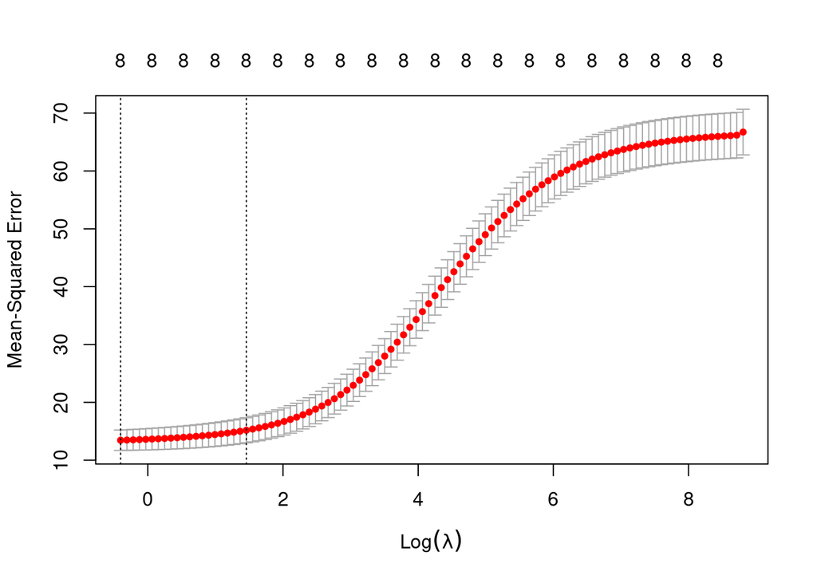

```r
# Ridge Regression
x <- model.matrix(mpg~.-name,Auto)
y <- Auto$mpg
### We are setting training sets for the explanatory variables x and response variable y
set.seed(1)
train <- sample(1:nrow(x), round(nrow(x))/2)

test <- (-train)

x.train <- x[train,]
y.train <- y[train]
### We are setting test sets for the explanatory variables x and response variable y
x.test <- x[test,]
y.test <- y[test]

library(glmnet)
grid <- 10^seq(10,-2,length=100)

ridge.mod <- glmnet(x.train, y.train, alpha = 0, lambda = grid, thresh = 1e-12)

set.seed (1)
cv.out <- cv.glmnet(x.train, y.train, alpha = 0)
plot(cv.out)
```

```r
bestlam.ridge <- cv.out$lambda.min
bestlam.ridge
```

```
## [1] 0.6685055
```

```r
ridge.pred <- predict(ridge.mod, s=bestlam.ridge, newx=x.test)
## This is MSE with the test set
ridge.MSE = mean((ridge.pred - y.test)^2)
out <- glmnet(x,y,alpha=0)
predict(out, type="coefficients", s=bestlam.ridge)
```

```
## 10 x 1 sparse Matrix of class "dgCMatrix"
##                         s1
## (Intercept)  -10.657921889
## (Intercept)    .
## cylinders     -0.374269119
## displacement  -0.001995191
## horsepower    -0.027950368
## weight        -0.003758905
## acceleration  -0.056238760
## year           0.667671576
## origin2        1.730832884
## origin3        2.463578649
```

Lasso:

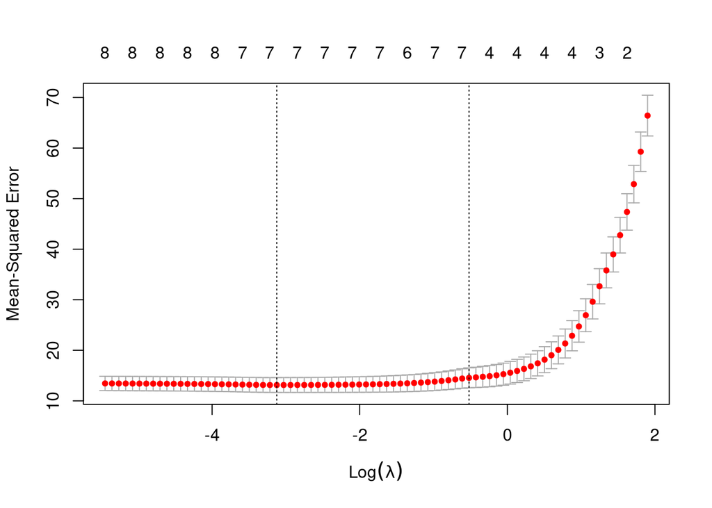

```r
# Lasso Regression
library(glmnet)
grid <- 10^seq(10,-2,length=100)

ridge.mod <- glmnet(x.train, y.train, alpha = 1, lambda = grid, thresh = 1e-12)

set.seed (1)
cv.out <- cv.glmnet(x.train, y.train, alpha = 1)
plot(cv.out)
```

```r
bestlam.lasso <- cv.out$lambda.min
bestlam.lasso
```

```
## [1] 0.0439832
```

```r
lasso.pred <- predict(ridge.mod, s=bestlam.lasso, newx=x.test)
## This is MSE with the test set
lasso.MSE = mean((lasso.pred - y.test)^2)
out <- glmnet(x,y,alpha=1)
predict(out, type="coefficients", s=bestlam.lasso)
```

```
## 10 x 1 sparse Matrix of class "dgCMatrix"
##                         s1
## (Intercept)  -17.151675928
## (Intercept)    .
## cylinders      .
## displacement   0.003862397
## horsepower    -0.008387145
## weight        -0.005926022
## acceleration   0.036278978
## year           0.750401531
## origin2        1.934253802
## origin3        2.250610994
```

### Questions for Auto Data

What can you conclude from the analysis?

In this case, since the lasso is close to zero, it is basically just doing full feature MLR. Additionally, CP and BIC produced the same formula so we have three models to choose from: Ridge, BIC/CP and R2.

Which one is the best?

What are λ for Lasso and Ridge regression?

Ridge Regression: 0.669

Lasso Regression: 0.044

Compare the MSE for Ridge regression with selected variables via Best Subset Selection and Lasso. What do you think? How are they different?

Adj R2 MSE: 10.41

CP MSE: 10.37

BIC MSE: 10.37

Ridge MSE: 10.97

Lasso MSE: 10.33

Do you think lasso is better or Ridge regression?

Although the Lasso MSE is better than Ridge, I think between the two ridge is still the better choice in this application. With a lambda so close to zero for lasso, we aren’t really leveraging the L1-norm penalty that makes it distinct from standard MLR. Therefore, it is better to leverage standard MLR techniques such as best subsets over lasso in this instance.

Which explanatory variables are contributing to “mpg”? Which variables are selected via best subset selection?

Stepwise: mpg ~ weight + year + origin

BIC: mpg ~ weight + year + origin

CP: mpg ~ weight + year + origin

Adj R2: mpg ~ horsepower + weight + year + origin

## Week 3: Take-Home Lab Exercise

Is Chicago Still Chiraq?

In this take-home lab exercise, you’ll update the previous analysis conducted on Chicago’s homicide rate to determine if things are improving or getting worse, as well as provide the best possible estimate for the leadership as to what is likely to happen next.

### Part 1: Data Acquisition and Cleaning

```r
#install.packages('data.table', 'ggplot2', 'plyr', 'xtable', dependencies=TRUE)
#library(devtools)
#install_github('ramnathv/rCharts', force= TRUE)
library(ggplot2)
library(plyr)
library(rmarkdown)
library(knitr)
library(base64enc)
library(xtable)


# Note: install these packages using the RStudio package manager
# forecast
# data.table
# devtools

library(forecast)
library(data.table)
library(Rcpp)
library(rCharts)
```

1.1 Go to Chicago’s data portal and download Chicago’s Homicide data for the period 1 January 2010 until 24 May 2023. The data portal is available at this web address:

https://data.cityofchicago.org/Public-Safety/Crimes-2001-to-present/ijzp-q8t2

1.2 Once there, open the “Crimes - 2001 to present - Dashboard.”

1.3 Use the “Date”” box (click and drag) and the “Primary Type” box (click on appropriate column) to subset the data to all homicides from 2010 until 2023. Then delete extra dates manually after you download the csv file from the website. Note that I get 7879 reported homicides in Chicago during this period as of June 3rd 2023.

1.4 Use the Export button at the top to export your filtered query.

1.5 Import the data as a .csv into your analysis environment (RStudio).

```r
#Crimes = read.csv('/home/sam/Documents/OA4106-Adv-Data_Analysis/Lab1/Crimes.csv')
#save(Crimes, file='Crimes.Rda')
load('Crimes.Rda')
Raw.Data = Crimes
```

```r
Series.Dates<-as.Date(Raw.Data$Date, '%m/%d/%Y')
Series.Dates<-data.table(Series.Dates)
Series.By.Day<-Series.Dates[,.N,by=.(mday(Series.Dates),month(Series.Dates),year(Series.Dates))][-c(1543,1575),]
Series.By.Month<-Series.Dates[,.N,by=.(month(Series.Dates),year(Series.Dates))]
Series.By.Month<-Series.By.Month[order(Series.By.Month$year,Series.By.Month$month),]
Series.By.Month<-Series.By.Month[-162,]
Series.By.Year<-Series.Dates[,.N,by=.(year(Series.Dates))]
Series.By.Day
```

```
##       mday month year N
##    1:    1     1 2011 2
##    2:    1     1 2013 3
##    3:    1     1 2016 3
##    4:    1     1 2017 2
##    5:    1     1 2018 4
##   ---
## 3663:   31    12 2016 2
## 3664:   31    12 2018 2
## 3665:   31    12 2020 1
## 3666:   31    12 2021 1
## 3667:   31    12 2022 2
```

```r
######## Reorganize and Reformat Dates
Series.Daily.Record<-data.frame(paste(rev(Series.By.Day$month), '/',
                             rev(Series.By.Day$mday), '/',
                             rev(Series.By.Day$year)),
                             as.numeric(rev(Series.By.Day$N)))
colnames(Series.Daily.Record)<-c('Date', 'Homicides')
Series.Daily.Record$Date<-as.Date(as.character(Series.Daily.Record$Date),  #Convert Text to Date
                                  format="%m / %d /%Y")
head(Series.Daily.Record)                 #Note the missing dates
```

```
##         Date Homicides
## 1 2022-12-31         2
## 2 2021-12-31         1
## 3 2020-12-31         1
## 4 2018-12-31         2
## 5 2016-12-31         2
## 6 2014-12-31         1
```

```r
Date.Range<-seq(min(Series.Daily.Record$Date), max(Series.Daily.Record$Date), 1)
Date.Homicides<-vector(mode="numeric", length=length(Date.Range))
for (i in 1:length(Date.Range)){
  if(Date.Range[i] %in% Series.Daily.Record$Date){
      Date.Homicides[i] <- Series.Daily.Record$Homicides[Series.Daily.Record$Date == Date.Range[i]]}
  else{Date.Homicides[i] <- 0}
}
head(data.frame(Date.Range, Date.Homicides)) #Confirm Problem Fixed
```

```
##   Date.Range Date.Homicides
## 1 2010-01-02              2
## 2 2010-01-03              1
## 3 2010-01-04              2
## 4 2010-01-05              0
## 5 2010-01-06              0
## 6 2010-01-07              1
```

### Part 2: Trend Analysis

Question 1: Provide the following in your written lab report:

Produce a graphic/visualization suitable for briefing a decision-maker that illustrates the observed data and your fitted trend (and anything else you think would be helpful).

```r
freq<-Date.Homicides
dates<-as.character(Date.Range)
plot.data<-data.frame(dates, freq)
n1 <- rCharts::Highcharts$new()
n1$yAxis(min=list(0),title=list(text='Chicago Homicides'))
n1$xAxis(categories = plot.data$dates, labels=list(rotation=-45,
         align='right'), tickInterval=365, title=list(text='Date'))
n1$series(name='Homicide Count',type='column',data = as.list(plot.data$freq),
          color = 'red')
n1$chart(zoomType='x')  #Allows you to select sub-sections for zoom
n1$save("n1daily.html", standalone = TRUE)
```

```r
Time<-paste(Series.By.Month$month, Series.By.Month$year)
freq<-Series.By.Month$N
plot.data<-data.frame(Time, freq)
n1 <- rCharts::Highcharts$new()
n1$title(text="Monthly Chicago Homicides 2010 - 2023")
n1$yAxis(min=list(0),title=list(text='Chicago Homicides'))
n1$xAxis(categories = plot.data$Time, labels=list(rotation=-45, align='right'), tickInterval=24, title=list(text='Date'))
n1$series(name='Homicide Count',type='column',data = as.list(plot.data$freq), color = 'red')
n1$chart(zoomType='x')  #Allows you to select sub-sections for zoom
n1$save("n1monthly.html", standalone = TRUE)
```

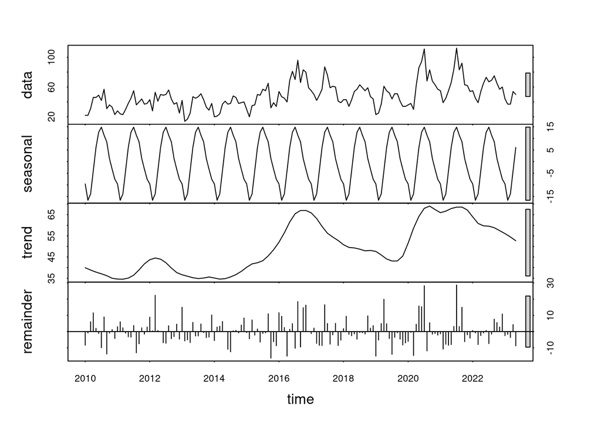

```r
#### Get Time Series Components for Seasonal Additive Model
Series.By.Month.TS<-ts(Series.By.Month$N, start=c(2010,1), freq=12)
seasonal.model<-stl(Series.By.Month.TS, s.window="periodic")
plot(seasonal.model)
```

```r
seasonal.model.trend<-as.vector(seasonal.model$time.series[,2])
seasonal.model.seasons<-seasonal.model$time.series[,1][1:12]
seasonal.fit<-as.vector(seasonal.model.trend+as.vector(seasonal.model$time.series[,1]))
head(seasonal.model$time.series)
```

```
##            seasonal    trend  remainder
## Jan 2010  -9.598391 39.95764 -8.3592498
## Feb 2010 -16.600883 39.41489 -0.8140064
## Mar 2010 -13.889092 38.87214  6.0169537
## Apr 2010  -3.897389 38.38734 11.5100439
## May 2010   6.094325 37.90255  2.0031241
## Jun 2010  12.644669 37.50011 -1.1447828
```

```r
Time<-paste(Series.By.Month$month, Series.By.Month$year)
freq<-Series.By.Month$N
plot.data<-data.frame(Time, freq, seasonal.model.trend, seasonal.fit)
n1 <- rCharts::Highcharts$new()
n1$title(text="Monthly Chicago Homicides 2010 - 2023")
n1$yAxis(min=list(0),title=list(text='Homicides'))
n1$xAxis(categories = plot.data$Time, labels=list(rotation=-45, align='right'), tickInterval=24, title=list(text='Date'))
n1$series(name='Homicide Count',type='column',data = as.list(plot.data$freq), color = 'red')
n1$series(name='Trend Line',type='line',data=as.list(plot.data$seasonal.model.trend), color='black')
n1$series(name='Fit Line',type='line',data=as.list(plot.data$seasonal.fit), color='grey')
n1$chart(zoomType='x')  #Allows you to select sub-sections for zoom
n1$save("n1model.html", standalone = TRUE)

Seasonal.Decomp.MAPE<-mean(abs(Series.By.Month.TS-seasonal.fit)/Series.By.Month.TS)
Seasonal.Decomp.MAPE
```

```
## [1] 0.1332262
```

```r
Seasonal.Decomp.MASE<-mean(abs(Series.By.Month.TS[13:161]-seasonal.fit[13:161]))/mean(abs(Series.By.Month.TS[13:161]-Series.By.Month.TS[1:149]))
Seasonal.Decomp.MASE
```

```
## [1] 0.5039892
```

### Seasonal Model Visualization

[interactive chart not shown]

Answer the following questions: Is the overall homicide rate getting better or worse in Chicago right now (i.e. what is the trend over the last couple of months)? Support your assertions using your analysis (a good visualization helps here).

As seen in the plot above, there is a negative trend occurring over the last three years. The 2020 spike coincides with the start of COVID-19 stay at home orders which were issued in late March 2020 in Illinois. Eddie Bocanegra, the senior director of Readi Chicago was quoted in a CNN article from JAN 2021 stating “I think Covid was the straw that broke the camel’s back… It’s almost like these communities were just having their heads above the water, and then Covid hit and they just sunk.” This theory is also supported by the negative trend in the four years leading up to the Covid stay at home orders.

### Part 3: Forecasting

Use the techniques/code you learned for time series forecasting in this week’s in-class lab to analyze the data you have downloaded in order to develop a forecast for the rest of the year.

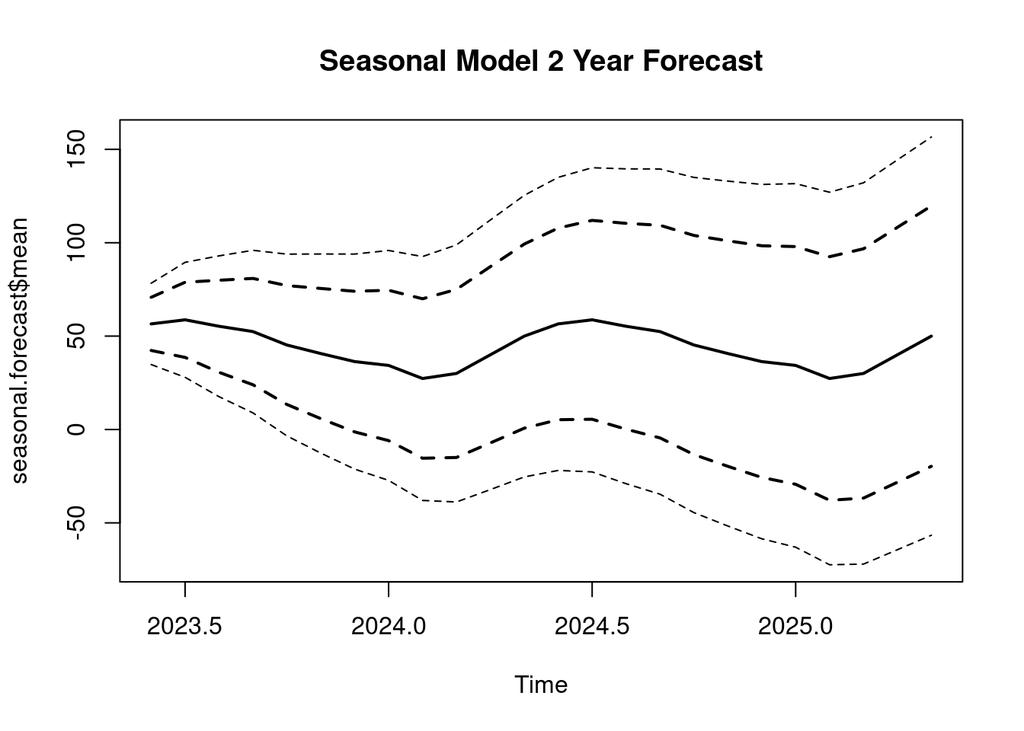

```r
seasonal.forecast<-forecast(seasonal.model, method='naive')
plot.ts(seasonal.forecast$mean, ylim=c(min(seasonal.forecast$lower[,2]),max(seasonal.forecast$upper[,2])), lwd=2,       # PlotForecast
        main='Seasonal Model 2 Year Forecast')
lines(seasonal.forecast$lower[,1], lwd=2, lty=2)            # 80% PI
lines(seasonal.forecast$upper[,1], lwd=2, lty=2)            # 80% PI
lines(seasonal.forecast$lower[,2], lwd=1, lty=2)            # 90% PI
lines(seasonal.forecast$upper[,2], lwd=1, lty=2)            # 90% PI
```

```r
toJSONArray2 <- function(obj, json = TRUE, names = TRUE, ...){
  value = lapply(1:nrow(obj), function(i) {
    res <- as.list(obj[i, ])
    if (!names) names(res) <- NULL  # remove names (e.g. {x = 1, y = 2} => {1, 2})
    return(res)
  })
  if (json){
    return(toJSON(value, .withNames = F, ...))
  } else {
    names(value) <- NULL;
    return(value)
  }
}

### Create Series for Forecast Plots By Appending 'NA' data as needed
seasonal.forecast.mean<-c(rep(NA, length=length(Series.By.Month.TS)), seasonal.forecast$mean[1:12])
seasonal.forecast.lower<-c(rep(NA, length=length(Series.By.Month.TS)), seasonal.forecast$lower[1:12,1])
seasonal.forecast.upper<-c(rep(NA, length=length(Series.By.Month.TS)), seasonal.forecast$upper[1:12,1])
Time.Add<-paste(c(rep(6:12), rep(1:5)), c(rep(2023,6), rep(2024, 5)))
Time.new<-c(Time, Time.Add)
freq.new<-c(Series.By.Month$N, rep(NA, 12))
seasonal.fit.new<-c(seasonal.fit, rep(NA, 12))
plot.data<-transform(data.frame(Time.new, freq.new, seasonal.fit.new, seasonal.forecast.mean,
              seasonal.forecast.lower, seasonal.forecast.upper))
n1 <- rCharts::Highcharts$new()
n1$yAxis(min=list(0),title=list(text='Chicago Homicides'))
n1$xAxis(categories = plot.data$Time.new, labels=list(rotation=-45, align='right'), tickInterval=24, title=list(text='Date'))
n1$series(
  name = '80% Forecast Interval',
  data = toJSONArray2(plot.data[,c('Time.new', 'seasonal.forecast.lower', 'seasonal.forecast.upper')], names = F, json = F),
  type = 'arearange',
  fillOpacity = 0.8,
  lineWidth = 0,
  color = 'lightgrey',
  zIndex = 0
)
n1$series(name='Homicide Count',type='column',data = as.list(plot.data$freq.new), color = 'red')
n1$series(name='Fit Line',type='line',data=as.list(plot.data$seasonal.fit.new), color='black')
n1$series(name='Forecast',type='line',data=as.list(plot.data$seasonal.forecast.mean), color='grey')
n1$chart(zoomType='x')  #Allows you to select sub-sections for zoom
n1$save("n1forecast.html", standalone = TRUE)
```

```r
Training.Series<-list()
Seasonal.model<-list()
Seasonal.Forecast<-list()
Naive.Forecast<-list()
Observed<-list()
Seasonal.Forecast.Errors<-list()
Naive.Forecast.Errors<-list()
for(i in 37:161){
  Training.Series[[i]]<-ts(Series.By.Month.TS[1:(i-1)], start=c(2010,1), freq=12)
  Naive.Forecast[[i]]<-as.vector(Series.By.Month.TS[(i-12):(i-1)])  #12 month forecast
  Seasonal.model[[i]]<-stl(Training.Series[[i]], s.window="periodic")
  Seasonal.Forecast[[i]]<-as.vector(forecast(Seasonal.model[[i]], method='naive')$mean)[1:12]
  Observed[[i]]<-as.vector(Series.By.Month.TS[i:(i+11)])
  Naive.Forecast.Errors[[i]]<-Observed[[i]]-Naive.Forecast[[i]] #12 months of error
  Seasonal.Forecast.Errors[[i]]<-Seasonal.Forecast[[i]]-Observed[[i]]
}

### Seasonal Model Performance Evaluation
Seasonal.Error.Table<-do.call(rbind, Seasonal.Forecast.Errors)
Naive.Error.Table<-do.call(rbind, Naive.Forecast.Errors)
Observed.Table<-do.call(rbind, Observed)
Seasonal.1Step.MAPE<-mean(abs(Seasonal.Error.Table[,1])/Observed.Table[,1])
Seasonal.1Yr.MAPE<-mean(abs(Seasonal.Error.Table[1:114,])/Observed.Table[1:114,])
Seasonal.1Step.MASE<-mean(abs(Seasonal.Error.Table[,1]))/mean(abs(Naive.Error.Table[,1]))
Seasonal.1Yr.MASE<-mean(abs(Seasonal.Error.Table[1:114,]))/mean(abs(Naive.Error.Table[1:114,]))
Seasonal.Decomp.MASE<-mean(abs(Series.By.Month.TS[13:161]-seasonal.fit[13:161]))/mean(abs(Series.By.Month.TS[13:161]-Series.By.Month.TS[1:149]))
Seasonal.Fitted.Performance<-c(Seasonal.Decomp.MAPE, Seasonal.Decomp.MASE)
Seasonal.Forecast.Performance.1<-c(Seasonal.1Yr.MAPE, Seasonal.1Yr.MASE)
Perf.Matrix.1<-rbind(Seasonal.Fitted.Performance, Seasonal.Forecast.Performance.1)
rownames(Perf.Matrix.1)<-c("Seasonal Fitted", "Seasonal Forecast (Rolling Horizon 1 Step)")
colnames(Perf.Matrix.1)<-c("MAPE", "MASE")
Perf.Matrix.1<-data.frame(Perf.Matrix.1)
Perf.Matrix.1<-knitr::kable(Perf.Matrix.1, digits=3, caption="Seasonal Decomposition Model Performance Comparison")
Perf.Matrix.1
```

Seasonal Decomposition Model Performance Comparison

|  | MAPE | MASE |
| --- | --- | --- |
| Seasonal Fitted | 0.133 | 0.504 |
| Seasonal Forecast (Rolling Horizon 1 Step) | 0.231 | 0.941 |

```r
# One Step Ahead Rolling Horizon Prediction
Training.Series<-list()
Naive.Forecast<-list()
Seasonal.model<-list()
Seasonal.Forecast<-list()
ARIMA.model<-list()
ARIMA.Forecast<-list()
HW.model<-list()
HW.Forecast<-list()
Observed<-list()
Naive.Forecast.Errors<-list()
HW.Forecast.Errors<-list()
ARIMA.Forecast.Errors<-list()
for(i in 37:161){    # Need 3 years of observation for setup of seasonal models so start at obs 36
  Training.Series[[i]]<-ts(Series.By.Month.TS[1:(i-1)], start=c(2010,1), freq=12)
  Naive.Forecast[[i]]<-as.vector(Series.By.Month.TS[(i-12):(i-1)])  #12 month forecast
  HW.model[[i]]<-ets(y=Training.Series[[i]],model='AAN')
  HW.Forecast[[i]]<-forecast(HW.model[[i]])$mean[1:12]  #12 month forecast
  Seasonal.model[[i]]<-stl(Training.Series[[i]], s.window="periodic")
  Seasonal.Forecast[[i]]<-as.vector(forecast(Seasonal.model[[i]], method='naive')$mean)[1:12]
  ARIMA.model[[i]]<-auto.arima(Training.Series[[i]])
  ARIMA.Forecast[[i]]<-forecast(ARIMA.model[[i]])$mean[1:12]  #12 month forecast
  Observed[[i]]<-as.vector(Series.By.Month.TS[i:(i+11)])  #next 12 month observations
  Seasonal.Forecast.Errors[[i]]<-Seasonal.Forecast[[i]]-Observed[[i]]
  Naive.Forecast.Errors[[i]]<-Observed[[i]]-Naive.Forecast[[i]] #12 months of error
  HW.Forecast.Errors[[i]]<-Observed[[i]]-HW.Forecast[[i]]
  ARIMA.Forecast.Errors[[i]]<-Observed[[i]]-ARIMA.Forecast[[i]]
  print(i)  #so we can see progress
}
ARIMA.1Step.Forecast<-do.call(rbind, ARIMA.Forecast)[,1]
HW.1Step.Forecast<-do.call(rbind, HW.Forecast)[,1]
Seasonal.1Step.Forecast<-do.call(rbind, Seasonal.Forecast)[,1]
Naive.1Step.Forecast<-do.call(rbind, Naive.Forecast)[,1]

##### HighChart of Forecasting Model 1-Step Ahead Performance
Time<-paste(Series.By.Month$month[37:161], Series.By.Month$year[37:161])
freq<-Series.By.Month$N[37:161]
x<-data.frame(Time, freq,  Seasonal.1Step.Forecast, HW.1Step.Forecast, ARIMA.1Step.Forecast)
n1 <- rCharts::Highcharts$new()
n1$yAxis(min=list(0),title=list(text='Homicide One Step Ahead Forecast Model Comparison'))
n1$xAxis(categories = x$Time, labels=list(rotation=-45, align='right'), tickInterval=24, title=list(text='Date'))
n1$series(name='Homicide Count',type='column',data = as.list(x$freq), color = 'red')
n1$series(name='Seasonal',type='line',data=as.list(x$Seasonal.1Step.Forecast), color='grey')
n1$series(name='ARIMA',type='line',data=as.list(x$ARIMA.1Step.Forecast), color='blue')
n1$series(name='AAN',type='line',data=as.list(x$HW.1Step.Forecast), color='green')
n1$chart(zoomType='x')  #Allows you to select sub-sections for zoom
n1$save("n1compare.html", standalone = TRUE)
```

```r
### Calculate MAPE Performance for 1 Step and 1 YR Forecasts
Observed.Table<-do.call(rbind, Observed)
Naive.Error.Table<-do.call(rbind, Naive.Forecast.Errors)
HW.Error.Table<-do.call(rbind, HW.Forecast.Errors)
ARIMA.Error.Table<-do.call(rbind, ARIMA.Forecast.Errors)
Naive.1Step.MAPE<-mean(abs(Naive.Error.Table[,1])/Observed.Table[,1])
Naive.1Yr.MAPE<-mean(abs(Naive.Error.Table[1:114,])/Observed.Table[1:114,])  #Full years end in 2022
Seasonal.1Step.MAPE<-mean(abs(Seasonal.Error.Table[,1])/Observed.Table[,1])
Seasonal.1Yr.MAPE<-mean(abs(Seasonal.Error.Table[1:114,])/Observed.Table[1:114,])  #Full years end in 2022

HW.1Step.MAPE<-mean(abs(HW.Error.Table[,1])/Observed.Table[,1])
HW.1Yr.MAPE<-mean(abs(HW.Error.Table[1:114,])/Observed.Table[1:114,])  #Full years end in 2014
ARIMA.1Step.MAPE<-mean(abs(ARIMA.Error.Table[,1])/Observed.Table[,1])
ARIMA.1Yr.MAPE<-mean(abs(ARIMA.Error.Table[1:114,])/Observed.Table[1:114,])  #Full years end in 2022


####### Calculate MASE Performance
Seasonal.1Step.MASE<-mean(abs(Seasonal.Error.Table[,1]))/mean(abs(Naive.Error.Table[,1]))
Seasonal.1Yr.MASE<-mean(abs(Seasonal.Error.Table[1:114,]))/mean(abs(Naive.Error.Table[1:114,]))
HW.1Step.MASE<-mean(abs(HW.Error.Table[,1]))/mean(abs(Naive.Error.Table[,1]))
HW.1Yr.MASE<-mean(abs(HW.Error.Table[1:114,]))/mean(abs(Naive.Error.Table[1:114,]))
ARIMA.1Step.MASE<-mean(abs(ARIMA.Error.Table[,1]))/mean(abs(Naive.Error.Table[,1]))
ARIMA.1Yr.MASE<-mean(abs(ARIMA.Error.Table[1:114,]))/mean(abs(Naive.Error.Table[1:114,]))

# Create the table rows
Naive.Performance<-cbind(Naive.1Step.MAPE, Naive.1Yr.MAPE, 1, 1)
Seasonal.Performance<-cbind(Seasonal.1Step.MAPE, Seasonal.1Yr.MAPE, Seasonal.1Step.MASE, Seasonal.1Yr.MASE)
HW.Performance<-cbind(HW.1Step.MAPE, HW.1Yr.MAPE, HW.1Step.MASE, HW.1Yr.MASE)
ARIMA.Performance<-cbind(ARIMA.1Step.MAPE, ARIMA.1Yr.MAPE, ARIMA.1Step.MASE, ARIMA.1Yr.MASE)

# Create the table for display
Performance.Matrix<-rbind(Naive.Performance, Seasonal.Performance, HW.Performance, ARIMA.Performance)
Performance.Matrix<-signif(Performance.Matrix, 2)
Performance.Matrix<-cbind(c("Naive", "Seasonal Decomposition", "Holt-Winters", "ARIMA"), Performance.Matrix)
Performance.Matrix<-data.frame(Performance.Matrix)
colnames(Performance.Matrix)<-c("Model", "1 Step MAPE", "12 Step MAPE", "1 Step MASE", "12 Step MASE")
Performance.Matrix<-knitr::kable(Performance.Matrix, digits=2) #prints a pretty table
Performance.Matrix
```

| Model | 1 Step MAPE | 12 Step MAPE | 1 Step MASE | 12 Step MASE |
| --- | --- | --- | --- | --- |
| Naive | 0.26 | 0.25 | 1 | 1 |
| Seasonal Decomposition | 0.2 | 0.23 | 0.75 | 0.94 |
| Holt-Winters | 0.22 | 0.35 | 0.82 | 1.4 |
| ARIMA | 0.2 | 0.25 | 0.75 | 1 |

```r
# Build and Evaluate an Ensemble Forecast
Seasonal.Forecast.Table<-na.omit(do.call(rbind, Seasonal.Forecast))
HW.Forecast.Table<-na.omit(do.call(rbind, HW.Forecast))
ARIMA.Forecast.Table<-na.omit(do.call(rbind, ARIMA.Forecast))
Ensemble.Forecast.Table<-(Seasonal.Forecast.Table + HW.Forecast.Table + ARIMA.Forecast.Table)/3
Ensemble.1Step.Forecast<-Ensemble.Forecast.Table[,1]
Ensemble.Error.Table<-Observed.Table-Ensemble.Forecast.Table[1:125,]
Ensemble.1Step.MAPE<-mean(abs(Ensemble.Error.Table[,1])/Observed.Table[,1])
Ensemble.1Yr.MAPE<-mean(abs(Ensemble.Error.Table[1:114,])/Observed.Table[1:114,])
Ensemble.1Step.MASE<-mean(abs(Ensemble.Error.Table[,1]))/mean(abs(Naive.Error.Table[,1]))
Ensemble.1Yr.MASE<-mean(abs(Ensemble.Error.Table[1:114,]))/mean(abs(Naive.Error.Table[1:114,]))

# Building rows of table again
Naive.Performance<-cbind(Naive.1Step.MAPE, Naive.1Yr.MAPE, 1, 1)
Seasonal.Performance<-cbind(Seasonal.1Step.MAPE, Seasonal.1Yr.MAPE, Seasonal.1Step.MASE, Seasonal.1Yr.MASE)
HW.Performance<-cbind(HW.1Step.MAPE, HW.1Yr.MAPE, HW.1Step.MASE, HW.1Yr.MASE)
ARIMA.Performance<-cbind(ARIMA.1Step.MAPE, ARIMA.1Yr.MAPE, ARIMA.1Step.MASE, ARIMA.1Yr.MASE)
Ensemble.Performance<-cbind(Ensemble.1Step.MAPE, Ensemble.1Yr.MAPE, Ensemble.1Step.MASE, Ensemble.1Yr.MASE)

# Building full table again
Performance.Matrix<-rbind(Naive.Performance, Seasonal.Performance, HW.Performance, ARIMA.Performance, Ensemble.Performance)
Performance.Matrix<-signif(Performance.Matrix, 2)
Performance.Matrix<-cbind(c("Naive", "Seasonal Decomposition", "Holt-Winters", "ARIMA",
                            "Ensemble"), Performance.Matrix)
Performance.Matrix<-data.frame(Performance.Matrix)
colnames(Performance.Matrix)<-c("Model", "1 Step MAPE", "12 Step MAPE", "1 Step MASE", "12 Step MASE")
Performance.Matrix<-knitr::kable(Performance.Matrix, digits=2, caption='Model Performance Comparison')
Performance.Matrix
```

Model Performance Comparison

| Model | 1 Step MAPE | 12 Step MAPE | 1 Step MASE | 12 Step MASE |
| --- | --- | --- | --- | --- |
| Naive | 0.26 | 0.25 | 1 | 1 |
| Seasonal Decomposition | 0.2 | 0.23 | 0.75 | 0.94 |
| Holt-Winters | 0.22 | 0.35 | 0.82 | 1.4 |
| ARIMA | 0.2 | 0.25 | 0.75 | 1 |
| Ensemble | 0.18 | 0.25 | 0.7 | 1 |

```r
n1$series(name='Ensemble',type='line',data=as.list(Ensemble.1Step.Forecast), color='black')
n1$save("n1ensemble.html", standalone = TRUE)
```

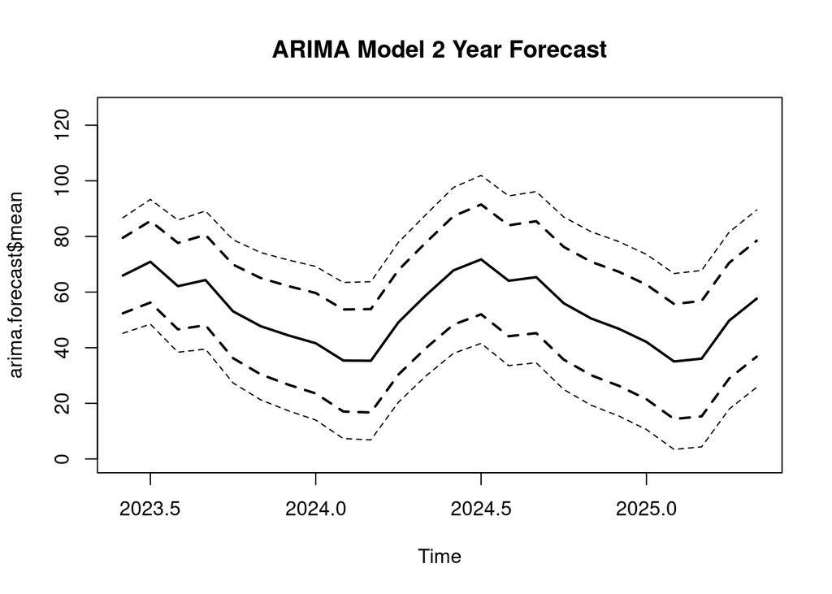

```r
#ARIMA Forecast
arima.model<-auto.arima(Series.By.Month.TS)

arima.forecast<-forecast(arima.model)
plot.ts(arima.forecast$mean, ylim=c(0,125), lwd=2,       # PlotForecast
        main='ARIMA Model 2 Year Forecast')
lines(arima.forecast$lower[,1], lwd=2, lty=2)            # 80% PI
lines(arima.forecast$upper[,1], lwd=2, lty=2)            # 80% PI
lines(arima.forecast$lower[,2], lwd=1, lty=2)            # 90% PI
lines(arima.forecast$upper[,2], lwd=1, lty=2)            # 90% PI
```

```r
arima.fit<-as.vector(arima.model$fitted)
```

```r
### Create Series for Forecast Plots By Appending 'NA' data as needed
Time<-paste(Series.By.Month$month, Series.By.Month$year)
freq<-Series.By.Month$N
arima.forecast.mean<-c(rep(NA, length=length(Series.By.Month.TS)), arima.forecast$mean[1:12])
arima.forecast.lower<-c(rep(NA, length=length(Series.By.Month.TS)), arima.forecast$lower[1:12,1])
arima.forecast.upper<-c(rep(NA, length=length(Series.By.Month.TS)), arima.forecast$upper[1:12,1])
Time.Add<-paste(c(rep(6:12), rep(1:5)), c(rep(2023,6), rep(2024, 5)))
Time.new<-c(Time, Time.Add)
freq.new<-c(Series.By.Month$N, rep(NA, 12))
arima.fit.new<-c(arima.fit, rep(NA, 12))
plot.data<-transform(data.frame(Time.new, freq.new, arima.fit.new, arima.forecast.mean,
              arima.forecast.lower, arima.forecast.upper))
n1 <- rCharts::Highcharts$new()
n1$yAxis(min=list(0),title=list(text='Chicago Homicides'))
n1$xAxis(categories = plot.data$Time.new, labels=list(rotation=-45, align='right'), tickInterval=24, title=list(text='Date'))
n1$series(
  name = '80% Forecast Interval',
  data = toJSONArray2(plot.data[,c('Time.new', 'arima.forecast.lower', 'arima.forecast.upper')], names = F, json = F),
  type = 'arearange',
  fillOpacity = 0.8,
  lineWidth = 0,
  color = 'lightgrey',
  zIndex = 0
)
n1$series(name='Homicide Count',type='column',data = as.list(plot.data$freq.new), color = 'red')
n1$series(name='Fit Line',type='line',data=as.list(plot.data$arima.fit.new), color='black')
n1$series(name='Forecast',type='line',data=as.list(plot.data$arima.forecast.mean), color='grey')
n1$chart(zoomType='x')  #Allows you to select sub-sections for zoom
n1$save("n1arimaforecast.html", standalone = TRUE)
```

Question 2: Provide the following in your written lab report:

Compare the short-term forecasting performance of at least three of the forecasting techniques you studied (you can use the seasonal Naive model as one of the techniques if you wish). Which of these techniques is best for this use case?

### Model Comparisons

[interactive chart not shown]

Model Performance Comparison

| Model | 1 Step MAPE | 12 Step MAPE | 1 Step MASE | 12 Step MASE |
| --- | --- | --- | --- | --- |
| Naive | 0.26 | 0.25 | 1 | 1 |
| Seasonal Decomposition | 0.2 | 0.23 | 0.75 | 0.94 |
| Holt-Winters | 0.22 | 0.35 | 0.82 | 1.4 |
| ARIMA | 0.2 | 0.25 | 0.75 | 1 |
| Ensemble | 0.18 | 0.25 | 0.7 | 1 |

As we are most concerned with short-term forecasting, we will focus on the 1 step model performance.

As seen in the performance matrix above, the averaged ensemble model is the most accurate, however development of a confidence interval is much more difficult for this model. For that reason, we will leverage the next highest performing model, ARIMA, for the forecast and accept slightly worse forecast performance for ease of confidence computation.

Provide a graphic/visualization illustrating your forecast (and your uncertainty in the forecast) for the rest of the year.

### ARIMA Model Forecast

[interactive chart not shown]

Provide a short written summary appropriate for leaders in government about what you expect to happen over the next year, especially during the summer months when crime peaks. Do you expect things to be better or worse this summer than last summer?

Based on the ARIMA Model forecast above, no worse than last summer at an 80% confidence level (upper range of grey interval). The model forecasts the peak to occur in July. Three of the last seven years also peaked in the month of July. The model also forecasts 70 murders in July which is consistent with the previous three year trend of roughly 10 less murders in July per year. The model also forecasts the low for 2024 to occur in Feb/Mar, consistent with 10 of the 13 years of the data. However, as this is 9 months out, the 80% confidence band is much wider than the summer forecast which is only two to three months.